# Stat_HW14_solution

```python
#載入所需函示庫

#載入所需函示庫
from matplotlib import pyplot as plt
%matplotlib inline
# 設定圖形大小; DPI越大圖越大
plt.rcParams["figure.dpi"] = 60
import seaborn as sns
import pandas as pd
import numpy as np
import scipy.stats as stats
import statsmodels.api as sm
import statsmodels.stats.api as sms
import statsmodels.formula.api as smf
import statsmodels.stats.multicomp as smm
import statsmodels.stats.outliers_influence as sso
import statsmodels
import statistics
import math

import warnings
warnings.filterwarnings("ignore")
```

```python
def Durbin_Watson_test(x):
    x_square_sum = np.vdot(x, x)
    print("x_square_sum = ", x_square_sum)
    size = x.size
    print("size = ", size)
    x_d = np.zeros((size))
    print("x_d = ", x_d)
    l_size = size - 1
    for i in range(l_size):
        x_d[i + 1] = x[i + 1] - x[i]
    print("x_d = ", x_d)
    d = np.vdot(x_d, x_d) / x_square_sum
    print("d = ", d)
    return(d)
```

```python
def runsTest(l, l_median):
    runs, n1, n2 = 1, 0, 0
    if(l[0]) >= l_median:
        n1 += 1
    else:
        n2 += 1
    for i in range(1, len(l)):
        if (l[i] >= l_median and l[i-1] < l_median) or (l[i] < l_median and l[i-1] >= l_median):
            runs += 1
        if(l[i]) >= l_median:
            n1 += 1
        else:
            n2 += 1
    runs_exp = ((2*n1*n2)/(n1+n2)) + 1
    stan_dev = math.sqrt((2*n1*n2*(2*n1*n2-n1-n2))/(((n1+n2)**2)*(n1+n2-1)))
    z = (runs-runs_exp)/stan_dev
    pval_z = stats.norm.sf(abs(z)) * 2
    print('runs = ', runs)
    print('n1 = ', n1)
    print('n2 = ', n2)
    print('runs_exp = ', runs_exp)
    print('stan_dev = ', stan_dev)
    print('z = ', z)
    print('pval_z = ', pval_z)
    return pval_z
```

```python
def SI_MA(y_v, n):
    y_v_MA_a = np.zeros(len(y_v))
    y_v_MA_a[:] = np.nan
    mvlen = n
    if n % 2 == 0:
        halfwin = int(mvlen / 2)
        y_v_MA_ta = np.zeros(len(y_v))
        for i in range(halfwin, len(y_v) - halfwin + 1):
            y_v_MA_ta[i] = np.mean(y_v[(i-halfwin): (i+halfwin)])
        for ii in range(halfwin, len(y_v) - halfwin):
            y_v_MA_a[ii] = np.mean(y_v_MA_ta[(ii): (ii+2)])
    else:
        halfwin = int((mvlen - 1) / 2)
        for i in range(halfwin, len(y_v) - halfwin):
            y_v_MA_a[i] = np.mean(y_v[(i-halfwin): (i+halfwin+1)])
    SI_MA_a = np.zeros(len(y_v))
    SI_MA_a[:] = np.nan
    SI_MA_a = y_v / y_v_MA_a
    SI_id_s = np.arange(1,len(y_v)+1)
    SI_id = SI_id_s - np.floor(SI_id_s / n) * n
    SI_id[np.where((SI_id[:] == 0))] = n
    SI_MA_a_df = pd.DataFrame({'SIMA': SI_MA_a, 'SIid': SI_id})
    SI_MA_u = np.zeros(n)
    for j in range(1,n+1):
        SI_MA_u[j-1] = SI_MA_a_df['SIMA'][SI_MA_a_df['SIid'] == j].dropna().mean()
    SI_MA = SI_MA_u / sum(SI_MA_u) * n
    print('Seasonal Index:', SI_MA)
    y_v_SI_MA = np.zeros(len(y_v))
    DSI_y_v = np.zeros(len(y_v))
    for k in range(0,len(y_v)):
        Idd = int(SI_MA_a_df['SIid'][k] - 1)
        y_v_SI_MA[k] = SI_MA[Idd]
        DSI_y_v[k] = y_v[k] / SI_MA[Idd]
    print('Deseasonalized Data:', DSI_y_v)
    SI_MA_result_a = np.array([SI_MA_a_df['SIid'], y_v_SI_MA, y_v, DSI_y_v])
    SI_MA_result_df = pd.DataFrame(SI_MA_result_a.T, columns = ['SID', 'SeaIdx', 'orig', 'Des_D'])
    return {"ma_ind":SI_MA, "SI_MA_res":SI_MA_result_df}
```

```python
def SI_LR(y_v, n):
    y_data = y_v
    X_data_ar = np.arange(1, len(y_v)+1)
    X_data_T = X_data_ar.T
    X_data = pd.DataFrame(X_data_T,columns = ['Time'])
    X_data = sm.add_constant(X_data)
    olsmod = sm.OLS(y_data, X_data)
    result_reg = olsmod.fit()
    st, data, ss2 = sso.summary_table(result_reg, alpha=0.05)
    y_v_LR_a = data[:, 2]
    SI_LR_a = y_v / y_v_LR_a
    SI_id_s = np.arange(1,len(y_v)+1)
    SI_id = SI_id_s - np.floor(SI_id_s / n) * n
    SI_id[np.where((SI_id[:] == 0))] = n
    SI_LR_a_df = pd.DataFrame({'SILR': SI_LR_a, 'SIid': SI_id})
    SI_LR_u = np.zeros(n)
    for j in range(1,n+1):
        SI_LR_u[j-1] = SI_LR_a_df['SILR'][SI_LR_a_df['SIid'] == j].dropna().mean()
    SI_LR = SI_LR_u / sum(SI_LR_u) * n
    print('Seasonal Index:', SI_LR)
    print('\n')
    y_v_SI_LR = np.zeros(len(y_v))
    DSI_y_v = np.zeros(len(y_v))
    for k in range(0,len(y_v)):
        Idd = int(SI_LR_a_df['SIid'][k] - 1)
        y_v_SI_LR[k] = SI_LR[Idd]
        DSI_y_v[k] = y_v[k] / SI_LR[Idd]
    print('Deseasonalized Data:', DSI_y_v)
    SI_LR_result_a = np.array([SI_LR_a_df['SIid'], y_v_SI_LR, y_v, DSI_y_v])
    SI_LR_result_df = pd.DataFrame(SI_LR_result_a.T, columns = ['SID', 'SeaIdx', 'orig', 'Des_D'])
    return {"LR_ind":SI_LR, "SI_LR_res":SI_LR_result_df}
```

```python
def ErrMetrix(y_v, f_v):
    y_v_n = pd.DataFrame({'orig': y_v})
    f_v_n = pd.DataFrame({'forecast': f_v})
    err1 = (y_v_n['orig'] - f_v_n['forecast']).dropna().values
    err1p = ((y_v_n['orig'] - f_v_n['forecast'])/ y_v_n['orig']).dropna().values
    MAD = round(np.absolute(err1).mean(),6)
    MSE = round(np.mean(err1 * err1),6)
    RMSE = round(np.sqrt(np.mean(err1 * err1)),6)
    MAPE = round(np.absolute(err1p).mean() * 100, 6)
    print("MAD = ", MAD)
    print("MSE = ", MSE)
    print("RMSE = ", RMSE)
    print("MAPE = ", MAPE, "%")
    return MAD, MSE, RMSE, MAPE
```

```python
df = pd.read_excel('Xr20-29.xlsx')
print('Head of dataset:')
display(df.head())
print("Tail of dataset:")
display(df.tail())
```

```
Head of dataset:
```

|  | Period | Quarter | Accounts receivable |
| --- | --- | --- | --- |
| 0 | 1 | 1 | 106 |
| 1 | 2 | 2 | 92 |
| 2 | 3 | 3 | 65 |
| 3 | 4 | 4 | 121 |
| 4 | 5 | 1 | 115 |

```
Tail of dataset:
```

|  | Period | Quarter | Accounts receivable |
| --- | --- | --- | --- |
| 11 | 12 | 4 | 140 |
| 12 | 13 | 1 | 121 |
| 13 | 14 | 2 | 111 |
| 14 | 15 | 3 | 82 |
| 15 | 16 | 4 | 163 |

```python
#調整期數從0開始
df["t"] = df["Period"]-1
df = df.drop(columns='Period')
print('Head of dataset:')
display(df.head())
print("Tail of dataset:")
display(df.tail())
```

```
Head of dataset:
```

|  | Quarter | Accounts receivable | t |
| --- | --- | --- | --- |
| 0 | 1 | 106 | 0 |
| 1 | 2 | 92 | 1 |
| 2 | 3 | 65 | 2 |
| 3 | 4 | 121 | 3 |
| 4 | 1 | 115 | 4 |

```
Tail of dataset:
```

|  | Quarter | Accounts receivable | t |
| --- | --- | --- | --- |
| 11 | 4 | 140 | 11 |
| 12 | 1 | 121 | 12 |
| 13 | 2 | 111 | 13 |
| 14 | 3 | 82 | 14 |
| 15 | 4 | 163 | 15 |

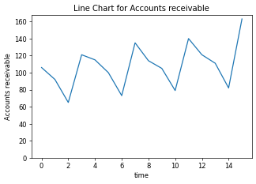

```python
#確認season內的期數與data相符
plt.plot(df['t'], df['Accounts receivable'])
plt.ylim(0, max(df['Accounts receivable'])+5)
plt.xlabel('time')
plt.ylabel('Accounts receivable')
plt.title('Line Chart for Accounts receivable')
plt.show()
```

According to the plot above, we can check that there are 4 periods in one season.

# CMV

```
Seasonal Index: [1.0919961  0.96289092 0.69417733 1.25093566]
Deseasonalized Data: [ 97.06994387  95.54560992  93.63601692  96.72759698 105.31173155
 103.85392383 105.16044977 107.91921977 104.39597736 109.04662002
 113.80377441 111.91622791 110.80625668 115.27785545 118.12543673
 130.30246535]
                            OLS Regression Results
==============================================================================
Dep. Variable:                  Des_D   R-squared:                       0.860
Model:                            OLS   Adj. R-squared:                  0.850
Method:                 Least Squares   F-statistic:                     86.09
Date:                Sun, 13 Jun 2021   Prob (F-statistic):           2.34e-07
Time:                        18:18:50   Log-Likelihood:                -42.503
No. Observations:                  16   AIC:                             89.01
Df Residuals:                      14   BIC:                             90.55
Df Model:                           1
Covariance Type:            nonrobust
==============================================================================
                 coef    std err          t      P>|t|      [0.025      0.975]
------------------------------------------------------------------------------
const         93.5241      1.759     53.158      0.000      89.751      97.298
t              1.8543      0.200      9.278      0.000       1.426       2.283
==============================================================================
Omnibus:                        4.656   Durbin-Watson:                   1.404
Prob(Omnibus):                  0.097   Jarque-Bera (JB):                2.377
Skew:                           0.897   Prob(JB):                        0.305
Kurtosis:                       3.586   Cond. No.                         17.0
==============================================================================

Notes:
[1] Standard Errors assume that the covariance matrix of the errors is correctly specified.
```

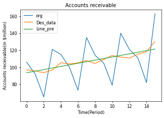

```python
#Seasonal index 與 deseasonalizing
df_SIMA = pd.DataFrame(columns=["ma_ind", "SI_MA_res"])
df_SIMA = SI_MA(df['Accounts receivable'], 4)

#SI
df_MA_Idx = df_SIMA["ma_ind"]
#各期Quarter, SI, ori, des
df_MA_Result = df_SIMA["SI_MA_res"]

#利用Des和Period(t)跑regression
y_data_df_MA = df_MA_Result['Des_D']
X_data_ar_df = np.array(df['t'])
X_data_ar_df_T = X_data_ar_df.T
X_data_df = pd.DataFrame(X_data_ar_df_T, columns = ['t'])
X_data_df = sm.add_constant(X_data_df)
olsmod_df_MA = sm.OLS(y_data_df_MA, X_data_df)
result_reg_df_MA = olsmod_df_MA.fit()
print(result_reg_df_MA.summary())

#linear regression之於各期的結果（desensonalized）
df_MA_st_2, df_MA_data_2, df_MA_ss2_2 = sso.summary_table(result_reg_df_MA, alpha=0.05)
df_MA_y_pre_2 = df_MA_data_2[:, 2]
des_pre_df_MA = df_MA_y_pre_2
#print(des_pre_df4_MA)

plt.plot(df['t'], df_MA_Result['orig'])
plt.plot(df['t'], df_MA_Result['Des_D'])
plt.plot(df['t'], des_pre_df_MA)
plt.legend(labels=['org', 'Des_data', 'Line_pre'])
plt.xlabel('Time(Period)')
plt.ylabel('Accounts receivable(in $million)')
plt.title('Accounts receivable')
plt.show()
```

### Requirements check.

```python
data = df_MA_data_2
y_pre = data[:, 2]
SD = data[:, 10]
```

#### Normality

H0 : Normal distributed  
H1 : Not normal distributed

```python
stat, p = stats.shapiro(SD)
print('Shapiro Test: Statistics=%f, p=%f' % (stat, p))
```

```
Shapiro Test: Statistics=0.927656, p=0.223750
```

Since p-value > alpha = 0.05, we can not reject H0 at significance level at alpha = 0.05.  
There is no evidence to show that it is not normally distributed.

#### Homoscedasticity

H0 : Homoscedasticity  
H1 : Not Homoscedasticity

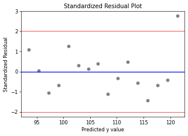

```python
plt.plot(y_pre, SD, 'o', color = 'gray')
plt.axhline(y=2, color = 'red', lw = 0.8)
plt.axhline(y=0, color = 'blue')
plt.axhline(y=-2, color = 'red', lw = 0.8)
plt.title('Standardized Residual Plot')
plt.xlabel('Predicted y value')
plt.ylabel('Standardized Residual')
plt.show()
```

We do not reject H0. We can assume the variation is constant and the mean is around 0.

#### Independence

H0 : Independence  
H1 : Not independence

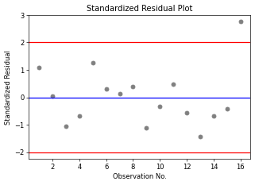

```
runs =  7
n1 =  8
n2 =  8
runs_exp =  9.0
stan_dev =  1.9321835661585918
z =  -1.0350983390135313
pval_z =  0.3006229881969068
p_value for Z-statistic=  0.3006229881969068
```

```python
Id = data[:, 0]
plt.plot(Id, SD, 'o', color = 'gray')
plt.axhline(y=0, color = 'blue')
plt.axhline(y=2, color = 'red')
plt.axhline(y=-2, color = 'red')
plt.title('Standardized Residual Plot')
plt.xlabel('Observation No.')
plt.ylabel('Standardized Residual')
plt.show()

SD_median = statistics.median(SD)
Z_pval = runsTest(SD, SD_median)
print('p_value for Z-statistic= ', Z_pval)
```

Since n1<=20 and n2<=20, we check with run table.  
lower bound = 4 < runs = 7 < upper bound = 14  
Thus, there is no evidence to infer the sample is not random selected.

#### According to the results above, all requirements are satisfied

#### Autocorreltaion

H0: The data are not first-order correlated  
H1: The data are first-order correlated

```python
d = Durbin_Watson_test(SD)
print(d)
```

```
x_square_sum =  16.914465145483355
size =  16
x_d =  [0. 0. 0. 0. 0. 0. 0. 0. 0. 0. 0. 0. 0. 0. 0. 0.]
x_d =  [ 0.         -1.04477876 -1.109879    0.37624543  1.93246743 -0.9495609
 -0.15596193  0.25314826 -1.50774208  0.78300931  0.81958834 -1.06467951
 -0.86613218  0.74632182  0.28403012  3.17732816]
d =  1.381325671272503
1.381325671272503
```

size = 16, k = 2(includes intercept), dL = 0.98013, dU = 1.23538  
Since dU < d= 1.381325671272503 < 4-dU, we can not reject H0.  
Thus, there is not enough evidence to infer that first order auto-correlation exist.  
We dont need to apply Autoregression model.

```python
#predict for the next year
Sea_pre_df_MA = des_pre_df_MA * df_MA_Result['SeaIdx']
New_t_2 = np.arange(16, 20, 1)
Total_t_2 = np.append(df['t'], New_t_2)
New_t_2 = sm.add_constant(New_t_2)
df_MA_des_pre_New_t_2 = result_reg_df_MA.predict(New_t_2)
print('New Des Prediction', df_MA_des_pre_New_t_2)
df_MA_Sea_pre_New_t_2 = df_MA_des_pre_New_t_2 * df_MA_Idx
print('New Seasonal Prediction', df_MA_Sea_pre_New_t_2)
New_Nan = np.zeros(New_t_2.shape[0])
New_Nan[:] = np.nan
```

```
New Des Prediction [123.19256576 125.04684477 126.90112378 128.75540279]
New Seasonal Prediction [134.52580119 120.40647108  88.09188298 161.06472427]
```

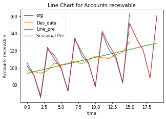

```python
df_MA_New_orig_2 = np.append(df_MA_Result['orig'], New_Nan)
df_MA_New_Des_D_2 = np.append(df_MA_Result['Des_D'], New_Nan)
df_MA_New_des_pre_2 = np.append(des_pre_df_MA, df_MA_des_pre_New_t_2)
df_MA_New_Sea_pre_2 = np.append(Sea_pre_df_MA, df_MA_Sea_pre_New_t_2)
df_MA_S_a = np.array([Total_t_2, df_MA_New_orig_2, df_MA_New_Des_D_2, df_MA_New_des_pre_2, df_MA_New_Sea_pre_2])
df_MA_S_df = pd.DataFrame(df_MA_S_a.T, columns=['time', 'org', 'Des_data', 'Line_pre', 'Seasonal Pre'])
#display(df_MA_S_df)

plt.plot(Total_t_2, df_MA_New_orig_2)
plt.plot(Total_t_2, df_MA_New_Des_D_2)
plt.plot(Total_t_2, df_MA_New_des_pre_2)
plt.plot(Total_t_2, df_MA_New_Sea_pre_2)
plt.legend(labels=['org', 'Des_data', 'Line_pre', 'Seasonal Pre'])
plt.xlabel('time')
plt.ylabel('Accounts receivable')
plt.title('Line Chart for Accounts receivable')
plt.show()
```

# SLR

```
Seasonal Index: [1.09390494 0.95793842 0.68778523 1.26037141]


Deseasonalized Data: [ 96.90055899  96.03957667  94.50624516  96.00344706 105.12796494
 104.39084421 106.13778303 107.11128391 104.21380872 109.61038642
 114.86143643 111.0783685  110.61290224 115.87383707 119.22326313
 129.32695761]
                            OLS Regression Results
==============================================================================
Dep. Variable:                  Des_D   R-squared:                       0.867
Model:                            OLS   Adj. R-squared:                  0.857
Method:                 Least Squares   F-statistic:                     91.11
Date:                Sun, 13 Jun 2021   Prob (F-statistic):           1.66e-07
Time:                        18:22:54   Log-Likelihood:                -41.985
No. Observations:                  16   AIC:                             87.97
Df Residuals:                      14   BIC:                             89.52
Df Model:                           1
Covariance Type:            nonrobust
==============================================================================
                 coef    std err          t      P>|t|      [0.025      0.975]
------------------------------------------------------------------------------
const         93.7125      1.703     55.019      0.000      90.059      97.366
t              1.8468      0.193      9.545      0.000       1.432       2.262
==============================================================================
Omnibus:                        1.359   Durbin-Watson:                   1.376
Prob(Omnibus):                  0.507   Jarque-Bera (JB):                0.703
Skew:                           0.510   Prob(JB):                        0.704
Kurtosis:                       2.880   Cond. No.                         17.0
==============================================================================

Notes:
[1] Standard Errors assume that the covariance matrix of the errors is correctly specified.
[ 93.71250513  95.55932664  97.40614816  99.25296968 101.0997912
 102.94661271 104.79343423 106.64025575 108.48707727 110.33389878
 112.1807203  114.02754182 115.87436334 117.72118485 119.56800637
 121.41482789]
```

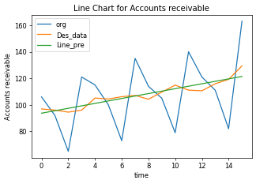

```python
df_SILR = pd.DataFrame(columns=["LR_ind", "SI_LR_res"])
df_SILR = SI_LR(df['Accounts receivable'], 4)
df_LR_Idx = df_SILR["LR_ind"]
df_LR_Result = df_SILR["SI_LR_res"]
y_data_df_LR = df_LR_Result['Des_D']
X_data_ar_df = np.array(df['t'])
X_data_ar_df_T = X_data_ar_df.T
X_data_df = pd.DataFrame(X_data_ar_df_T, columns = ['t'])
X_data_df = sm.add_constant(X_data_df)
olsmod_df_LR = sm.OLS(y_data_df_LR, X_data_df)
result_reg_df_LR = olsmod_df_LR.fit()
print(result_reg_df_LR.summary())
df_LR_st_2, df_LR_st_data_2, df_LR_st_ss2_2 = sso.summary_table(result_reg_df_LR, alpha=0.05)
df_LR_st_y_pre_2 = df_LR_st_data_2[:, 2]
df_LR_st_SD_2 = df_LR_st_data_2[:, 10]
des_pre_df_LR = df_LR_st_y_pre_2
print(des_pre_df_LR)
plt.plot(df['t'], df_LR_Result['orig'])
plt.plot(df['t'], df_LR_Result['Des_D'])
plt.plot(df['t'], des_pre_df_LR)
plt.legend(labels=['org', 'Des_data', 'Line_pre'])
plt.xlabel('time')
plt.ylabel('Accounts receivable')
plt.title('Line Chart for Accounts receivable')
plt.show()
```

### Requirements check.

```python
data = df_LR_st_data_2
y_pre = data[:, 2]
SD = data[:, 10]
```

#### Normality

H0 : Normal distributed  
H1 : Not normal distributed

```python
stat, p = stats.shapiro(SD)
print('Shapiro Test: Statistics=%f, p=%f' % (stat, p))
```

```
Shapiro Test: Statistics=0.961965, p=0.697559
```

Since p-value > alpha = 0.05, we can not reject H0 at significance level at alpha = 0.05.  
There is no evidence to show that it is not normally distributed.

#### Homoscedasticity

H0 : Homoscedasticity  
H1 : Not Homoscedasticity

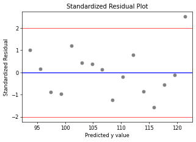

```python
plt.plot(y_pre, SD, 'o', color = 'gray')
plt.axhline(y=2, color = 'red', lw = 0.8)
plt.axhline(y=0, color = 'blue')
plt.axhline(y=-2, color = 'red', lw = 0.8)
plt.title('Standardized Residual Plot')
plt.xlabel('Predicted y value')
plt.ylabel('Standardized Residual')
plt.show()
```

We do not reject H0. We can assume the variation is constant and the mean is around 0.

#### Independence

H0 : Independence  
H1 : Not independence

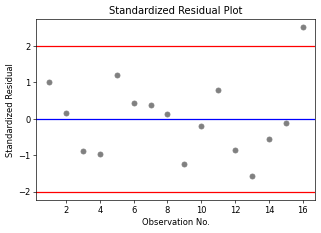

```
runs =  7
n1 =  8
n2 =  8
runs_exp =  9.0
stan_dev =  1.9321835661585918
z =  -1.0350983390135313
pval_z =  0.3006229881969068
p_value for Z-statistic=  0.3006229881969068
```

```python
Id = data[:, 0]
plt.plot(Id, SD, 'o', color = 'gray')
plt.axhline(y=0, color = 'blue')
plt.axhline(y=2, color = 'red')
plt.axhline(y=-2, color = 'red')
plt.title('Standardized Residual Plot')
plt.xlabel('Observation No.')
plt.ylabel('Standardized Residual')
plt.show()

SD_median = statistics.median(SD)
Z_pval = runsTest(SD, SD_median)
print('p_value for Z-statistic= ', Z_pval)
```

Since n1<=20 and n2<=20, we check with run table.  
lower bound = 4 < runs = 7 < upper bound = 14  
Thus, there is no evidence to infer the sample is not random selected.

#### According to the results above, all requirements are satisfied

#### Autocorreltaion

H0: The data are not first-order correlated  
H1: The data are first-order correlated

```python
d = Durbin_Watson_test(SD)
print(d)
```

```
x_square_sum =  16.66750082228322
size =  16
x_d =  [0. 0. 0. 0. 0. 0. 0. 0. 0. 0. 0. 0. 0. 0. 0. 0.]
x_d =  [ 0.         -0.86773423 -1.03169069 -0.08968246  2.16130328 -0.76694846
 -0.03169471 -0.25414769 -1.37398012  1.02737218  0.99396593 -1.65443049
 -0.7033143   1.01184088  0.45497822  2.63117057]
d =  1.347975870976776
1.347975870976776
```

size = 16, k = 2(includes intercept), dL = 0.98013, dU = 1.23538  
Since dU < d= 1.347975870976776 < 4-dU, we can not reject H0.  
Thus, there is not enough evidence to infer that first order auto-correlation exist.  
We dont need to apply Autoregression model.

```
New Des Prediction [123.26164941 125.10847092 126.95529244 128.80211396]
New Seasonal Prediction [134.83652699 119.84621053  87.31797559 162.33850206]
```

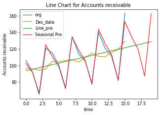

```python
Sea_pre_df_LR = des_pre_df_LR * df_LR_Result['SeaIdx']
New_t_2 = np.arange(16, 20, 1)
Total_t_2 = np.append(df['t'], New_t_2)
New_t_2 = sm.add_constant(New_t_2)
df_LR_st_des_pre_New_t_2 = result_reg_df_LR.predict(New_t_2)
print('New Des Prediction', df_LR_st_des_pre_New_t_2)
df_LR_st_Sea_pre_New_t_2 = df_LR_st_des_pre_New_t_2 * df_LR_Idx
print('New Seasonal Prediction', df_LR_st_Sea_pre_New_t_2)
New_Nan = np.zeros(New_t_2.shape[0])
New_Nan[:] = np.nan

df_LR_st_New_orig_2 = np.append(df_LR_Result['orig'], New_Nan)
df_LR_st_New_Des_D_2 = np.append(df_LR_Result['Des_D'], New_Nan)
df_LR_st_New_des_pre_2 = np.append(des_pre_df_LR, df_LR_st_des_pre_New_t_2)
df_LR_st_New_Sea_pre_2 = np.append(Sea_pre_df_LR, df_LR_st_Sea_pre_New_t_2)
plt.plot(Total_t_2, df_LR_st_New_orig_2)
plt.plot(Total_t_2, df_LR_st_New_Des_D_2)
plt.plot(Total_t_2, df_LR_st_New_des_pre_2)
plt.plot(Total_t_2, df_LR_st_New_Sea_pre_2)
plt.legend(labels=['org', 'Des_data', 'Line_pre', 'Seasonal Pre'])
plt.xlabel('time')
plt.ylabel('Accounts receivable')
plt.title('Line Chart for Accounts receivable')
plt.show()
```

# Dummy

```
                             OLS Regression Results
===============================================================================
Dep. Variable:     Accounts receivable   R-squared:                       0.969
Model:                             OLS   Adj. R-squared:                  0.958
Method:                  Least Squares   F-statistic:                     86.83
Date:                 Sun, 13 Jun 2021   Prob (F-statistic):           3.03e-08
Time:                         18:24:55   Log-Likelihood:                -46.442
No. Observations:                   16   AIC:                             102.9
Df Residuals:                       11   BIC:                             106.7
Df Model:                            4
Covariance Type:             nonrobust
==============================================================================
                 coef    std err          t      P>|t|      [0.025      0.975]
------------------------------------------------------------------------------
const        123.2125      3.772     32.666      0.000     114.911     131.514
t              1.8375      0.297      6.181      0.000       1.183       2.492
Quarter_1    -20.2375      3.864     -5.237      0.000     -28.743     -11.732
Quarter_2    -34.0750      3.807     -8.951      0.000     -42.454     -25.696
Quarter_3    -63.1625      3.772    -16.746      0.000     -71.464     -54.861
==============================================================================
Omnibus:                        7.037   Durbin-Watson:                   1.780
Prob(Omnibus):                  0.030   Jarque-Bera (JB):                3.893
Skew:                           0.942   Prob(JB):                        0.143
Kurtosis:                       4.513   Cond. No.                         41.4
==============================================================================

Notes:
[1] Standard Errors assume that the covariance matrix of the errors is correctly specified.
[102.975  90.975  63.725 128.725 110.325  98.325  71.075 136.075 117.675
 105.675  78.425 143.425 125.025 113.025  85.775 150.775]
```

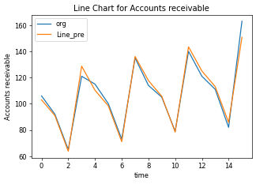

```python
#轉換Quarter to Dummy variables
Quarter_dummy = pd.get_dummies(df['Quarter'], prefix = 'Quarter')
df_d = pd.concat([df, Quarter_dummy], axis = 1)
df_d.head()
y_data_df_d = df_d['Accounts receivable']
X_data_ar_df_d = np.array([df_d['t'], df_d['Quarter_1'], df_d['Quarter_2'], df_d['Quarter_3']])
X_data_ar_df_d_T = X_data_ar_df_d.T
X_data_df_d = pd.DataFrame(X_data_ar_df_d_T, columns = ['t', 'Quarter_1', 'Quarter_2', 'Quarter_3'])
X_data_df_d = sm.add_constant(X_data_df_d)

#regression
olsmod_df_d_DM = sm.OLS(y_data_df_d, X_data_df_d)
result_reg_df_d_DM = olsmod_df_d_DM.fit()
print(result_reg_df_d_DM.summary())
df_d_DM_st, df_d_DM_data, df_d_DM_ss2 = sso.summary_table(result_reg_df_d_DM, alpha=0.05)

#regression results
df_d_DM_y_pre = df_d_DM_data[:, 2]
df_d_DM_SD = df_d_DM_data[:, 10]
des_pre_df_d_DM = df_d_DM_y_pre
print(des_pre_df_d_DM)
plt.plot(df_d['t'], df_d['Accounts receivable'])
plt.plot(df_d['t'], des_pre_df_d_DM)
plt.legend(labels=['org', 'Line_pre'])
plt.xlabel('time')
plt.ylabel('Accounts receivable')
plt.title('Line Chart for Accounts receivable')
plt.show()
```

### Requirements check.

```python
data = df_d_DM_data
y_pre = data[:, 2]
SD = data[:, 10]
```

#### Normality

H0 : Normal distributed  
H1 : Not normal distributed

```python
stat, p = stats.shapiro(SD)
print('Shapiro Test: Statistics=%f, p=%f' % (stat, p))
```

```
Shapiro Test: Statistics=0.921701, p=0.179648
```

Since p-value > alpha = 0.05, we can not reject H0 at significance level at alpha = 0.05.  
There is no evidence to show that it is not normally distributed.

#### Homoscedasticity

H0 : Homoscedasticity  
H1 : Not Homoscedasticity

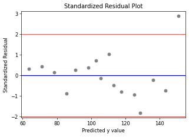

```python
plt.plot(y_pre, SD, 'o', color = 'gray')
plt.axhline(y=2, color = 'red', lw = 0.8)
plt.axhline(y=0, color = 'blue')
plt.axhline(y=-2, color = 'red', lw = 0.8)
plt.title('Standardized Residual Plot')
plt.xlabel('Predicted y value')
plt.ylabel('Standardized Residual')
plt.show()
```

We do not reject H0. We can assume the variation is constant and the mean is around 0.

#### Independence

H0 : Independence  
H1 : Not independence

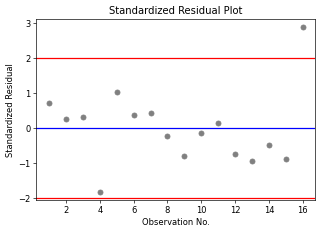

```
runs =  7
n1 =  8
n2 =  8
runs_exp =  9.0
stan_dev =  1.9321835661585918
z =  -1.0350983390135313
pval_z =  0.3006229881969068
p_value for Z-statistic=  0.3006229881969068
```

```python
Id = data[:, 0]
plt.plot(Id, SD, 'o', color = 'gray')
plt.axhline(y=0, color = 'blue')
plt.axhline(y=2, color = 'red')
plt.axhline(y=-2, color = 'red')
plt.title('Standardized Residual Plot')
plt.xlabel('Observation No.')
plt.ylabel('Standardized Residual')
plt.show()

SD_median = statistics.median(SD)
Z_pval = runsTest(SD, SD_median)
print('p_value for Z-statistic= ', Z_pval)
```

Since n1<=20 and n2<=20, we check with run table.  
lower bound = 4 < runs = 7 < upper bound = 14  
Thus, there is no evidence to infer the sample is not random selected.

#### According to the results above, all requirements are satisfied

#### Autocorreltaion

H0: The data are not first-order correlated  
H1: The data are first-order correlated

```python
d = Durbin_Watson_test(SD)
print(d)
```

```
x_square_sum =  16.83710503809795
size =  16
x_d =  [0. 0. 0. 0. 0. 0. 0. 0. 0. 0. 0. 0. 0. 0. 0. 0.]
x_d =  [ 0.         -0.47105448  0.05888181 -2.11974517  2.84316948 -0.65693361
  0.05474447 -0.65693361 -0.56934246  0.65693361  0.27372234 -0.87591148
 -0.19799794  0.47105448 -0.41217267  3.76843586]
d =  1.7757423389509335
1.7757423389509335
```

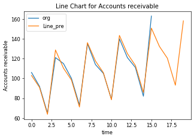

```python
New_t_2 = np.array([[16, 1, 0, 0],
                    [17, 0, 1, 0],
                    [18, 0, 0, 1],
                    [19, 0, 0, 0]])
Total_t_2 = np.append(df_d['t'], New_t_2[:,0])
New_t_2 = sm.add_constant(New_t_2)
df_d_DM_pre_New_t = result_reg_df_d_DM.predict(New_t_2)
#print(df_d_DM_pre_New_t)
New_Nan = np.zeros(New_t_2.shape[0])
New_Nan[:] = np.nan

df_d_DM_New_orig = np.append(df_d['Accounts receivable'], New_Nan)
df_d_DM_New_pre = np.append(des_pre_df_d_DM, df_d_DM_pre_New_t)
plt.plot(Total_t_2, df_d_DM_New_orig)
plt.plot(Total_t_2, df_d_DM_New_pre)
plt.legend(labels=['org', 'Line_pre'])
plt.xlabel('time')
plt.ylabel('Accounts receivable')
plt.title('Line Chart for Accounts receivable')
plt.show()
```

# Comparison

```python
print('Error Metrics for Seasonal Index by Moving Average')
MA_Err_M = ErrMetrix(df['Accounts receivable'], Sea_pre_df_MA)
print('\n')
print('Error Metrics for Seasonal Index by LR')
LR_Err_M = ErrMetrix(df['Accounts receivable'], Sea_pre_df_LR)
print('\n')
print('Error Metrics for LR Dummy')
DM_Err_M = ErrMetrix(df['Accounts receivable'], des_pre_df_d_DM)
```

```
Error Metrics for Seasonal Index by Moving Average
MAD =  2.900542
MSE =  15.373322
RMSE =  3.920883
MAPE =  2.488196 %


Error Metrics for Seasonal Index by LR
MAD =  2.875548
MSE =  14.435685
RMSE =  3.799432
MAPE =  2.479523 %


Error Metrics for LR Dummy
MAD =  3.3
MSE =  19.440625
RMSE =  4.409152
MAPE =  2.861405 %
```

```python
ErrM_id = ['MAD', 'MSE', 'RMSE', 'MAPE']
ErrM_a = np.array([ErrM_id, MA_Err_M, LR_Err_M, DM_Err_M])
ErrM_df = pd.DataFrame(ErrM_a.T, columns = ['ErrM', 'SIMA', 'SILR', 'Dummy'])
print('dataset:')
display(ErrM_df)
```

```
dataset:
```

|  | ErrM | SIMA | SILR | Dummy |
| --- | --- | --- | --- | --- |
| 0 | MAD | 2.900542 | 2.875548 | 3.3 |
| 1 | MSE | 15.373322 | 14.435685 | 19.440625 |
| 2 | RMSE | 3.920883 | 3.799432 | 4.409152 |
| 3 | MAPE | 2.488196 | 2.479523 | 2.861405 |

#### According to the table above, we can see that SILR performs the best no matter which measurement method we use.